# Assignment 1: Analysis of burials from the Corded Ware culture

Author

Rodrigo de Jesús Muñoz García

Published

April 26, 2024

## Libraries

```r
library(readxl)
library(dplyr)
library(tidyr)
```

## Questions

1. Load the burial characteristics data from the **All_burials** sheet in an object called `graves`. Also load the grave location data from the **Database_references** sheet in an object called `locations` .

```r
graves <- read_excel("data/corded_ware_burials.xlsx", sheet = "All_burials")

locations <- read_excel("data/corded_ware_burials.xlsx", sheet = "Database_references")
```

2. Make an R-statement, whose output is a **single** `TRUE` or `FALSE`, that checks whether all graves found in the `All_burials` sheet are present in the `Database_references` sheet and, conversely, that all graves in the **Database_references** sheet are present in the **All_burials** sheet.

```r
gra_in_loc <- all(graves$"Grave ID" %in% locations$"Grave ID")

loc_in_gra <- all(locations$"Grave ID" %in% graves$"Grave ID")


gra_in_loc && loc_in_gra
```

```
[1] TRUE
```

3. The columns `Left Flexed`, `Right Flexed`, `Extended`, `Seated` in the table `All_burials` give the orientation of the body. Only one of these can be the body position, which means that the sum of these columns should be 0 (unknown position) or 1. Make an R-statement, whose output is a single `TRUE` or `FALSE`, that checks whether this is indeed the case.

   ```r
   body_position <- rowSums(graves[, c("Left Flexed", "Right Flexed", "Extended", "Seated")]) %in% c(0, 1)

   all(body_position)
   ```

   ```
   [1] TRUE
   ```

4. Make the new data frame `artifacts` that contains the four columns listed above. The table should only contain rows where the number of artifacts is not equal to 0. You probably want to use functions from the `dplyr` and `tidyr` packages as demonstrated in the [Data wrangling](https://few.vu.nl/~molenaar/courses/StatR/chapters/B-10-wrangling.html) chapter of the syllabus. *Display the head, the first 6 rows, of your `artifacts` object (no caption needed)*.

   ```r
   artifact_cols <- grep("^pos_", names(graves), value = TRUE)

   artifacts <- data.frame()

   for (col in artifact_cols) {
     # Get type
     artifact_type <- gsub("^pos_", "", col)
     artifact_type <- gsub("\\..*", "", artifact_type)

     # Get pos
     position <- as.integer(gsub("^.*\\.", "", col))

     # Filter 0
     filtered <- graves %>%
       filter(get(col) != 0) %>%
       select("Grave ID", !!sym(col))

     # Name column
     colnames(filtered)[2] <- "Number"

     artifacts <- bind_rows(artifacts, mutate(filtered, Artifact = artifact_type, Position = position))
   }

   # Displaying the head of the artifacts data frame
   head(artifacts)
   ```

   ```
     Grave ID Number    Artifact Position
   1       52      1 Amber beads        1
   2      784      1 Amber beads        1
   3      919      1 Amber beads        1
   4     1003      1 Amber beads        1
   5     1305      1 Amber beads        1
   6     1315      1 Amber beads        1
   ```

5. Add the column `Orientation` to the `location` object as listed above. **Tip:** One way to achieve this is to first create an intermediary `orientation` data frame with columns `Grave ID` and the new `Orientation` column and to subsequently join this with the `location` data frame. Please see the help on the different `join` functions from `dplyr` to choose the right one. *Display the head of the modified `locations` table (no caption needed)*.The `echo: false` option disables the printing of code (only output is displayed).

   ```r
   orientation <- transmute(graves, `Grave ID`, Orientation = case_when(
     graves$"Left Flexed" == 1 ~ "Left Flexed",
     graves$"Right Flexed" == 1 ~ "Right Flexed",
     graves$Extended == 1 ~ "Extended",
     graves$Seated == 1 ~ "Seated",
     TRUE ~ "Unknown"
   ))


   locations <- left_join(locations, orientation, by = "Grave ID")

   locations <- select(locations, `Grave ID`, Orientation, everything())


   head(locations)
   ```

   ```
   # A tibble: 6 × 8
     `Grave ID` Orientation  Country        Province Toponym  `Registration number`
          <dbl> <chr>        <chr>          <chr>    <chr>    <chr>
   1       2206 Left Flexed  Czech Republic Moravia  Zadní r… 25.4.2 Grave 1
   2       2207 Left Flexed  Czech Republic Moravia  Brno -S… 30.1.1 Grave 9
   3       2208 Right Flexed Czech Republic Moravia  Brno -S… 30.1.2 Grave VN 1
   4       2209 Unknown      Czech Republic Moravia  Brno -S… 30.1.3 Grave 42 VN 1
   5       2210 Right Flexed Czech Republic Moravia  Bučovice 35.1.2  Grave 2 (VN …
   6       2211 Right Flexed Czech Republic Moravia  Cow bar… 72.1.2 Grave 2 (VN 2)
   # ℹ 2 more variables: Bibliography <chr>, `Catalogue no` <chr>
   ```

6. Make a table that lists total numbers of graves, number of graves with amber artifacts (*Amber objects*, *Amber beads*) and the percentage of graves with amber artifacts, differentiated by country.

   ```r
   # Extract unique Grave with amber
   amber_graves <- unique(artifacts[grepl("Amber", artifacts$Artifact), "Grave ID"])

   # IDs with countries
   amber_with_country <- merge(data.frame(Frequency = amber_graves), locations, by.x = "Frequency", by.y = "Grave ID", all.x = TRUE)

   # Count
   amber_graves_count <- aggregate(Frequency ~ Country, data = amber_with_country, FUN = function(x) length(unique(x)))

   # Get country names and frequencies
   country_freq <- as.data.frame(table(locations$Country))
   colnames(country_freq) <- c("Country", "Frequency")

   # Merge amber_graves_count with country_freq on the "Country" column
   result_amber <- merge(amber_graves_count, country_freq, by = "Country", all.x = TRUE)

   # Calculate the percentage
   result_amber$Percentage <- (result_amber$Frequency.x / result_amber$Frequency.y) * 100

   result_amber
   ```

   ```
     Country Frequency.x Frequency.y Percentage
   1 Denmark         166         819 20.2686203
   2 Germany           1         154  0.6493506
   ```

6.1 Draw a brief conclusion about our hypothesis that there may have been trade between the different regions in northern Europe during the Corded Ware period:  
**Based on the data concerning amber artifacts, there is no discernible evidence of inter-country trade. However, indications suggest that amber trade may have been prevalent in Denmark, as it is frequently discovered in approximately 20% of graves.**

7. To check the assertion by Bourgeois and Kroon (2017) that male burials were more homogeneous than female burials, make a barplot, like one of those in Figure 3 in the paper, that displays the percentage of *Flint daggers and blades* per position relative to the body in the grave (numbers 1–8). However, in your figure differentiate by left- or right-flexed body orientation.

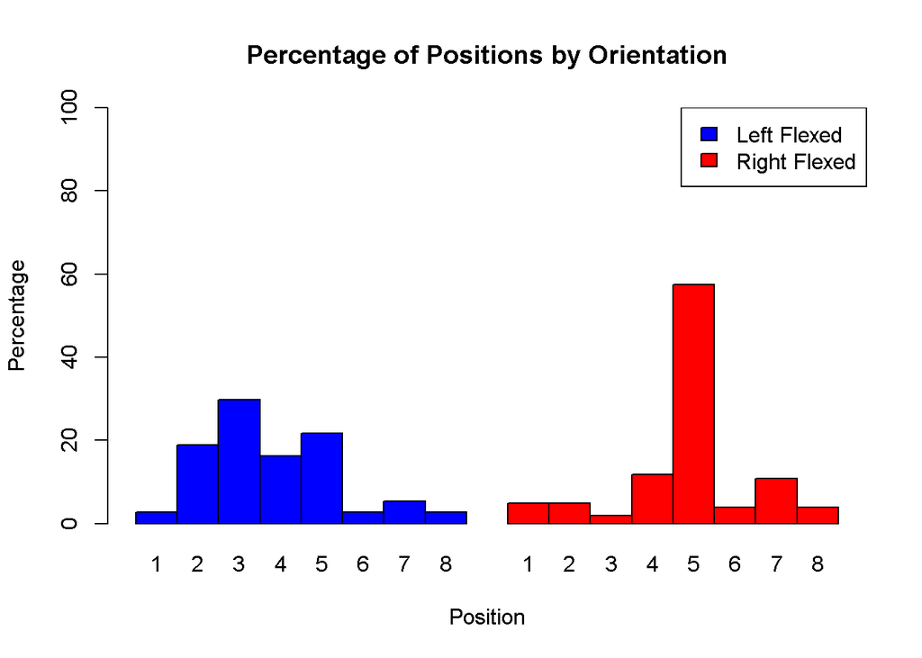

   ```r
   # Subset "Flint blades"
   flint_artifacts <- artifacts[grepl("Flint daggers and blades", artifacts$Artifact), ]

   # Subset  "left-flexed" or "right-flexed"
   flexed_orientations <- locations[locations$Orientation %in% c("Left Flexed", "Right Flexed"), ]

   # Filter flint_artifacts
   flint_artifacts <- merge(flint_artifacts, flexed_orientations[c("Grave ID", "Orientation")], by = "Grave ID", all.x = TRUE)

   # Calculate frequency
   position_counts <- table(flint_artifacts$Position)
   position_df <- as.data.frame(position_counts)
   colnames(position_df) <- c("Position", "Frequency")
   position_df <- position_df[order(position_df$Position), ]

   # Filter flint_artifacts
   left_flexed_df <- flint_artifacts[flint_artifacts$Orientation == "Left Flexed", ]

   right_flexed_df <- flint_artifacts[flint_artifacts$Orientation == "Right Flexed", ]

   # Calculate frequency flexed orientations
   left_flexed_counts <- table(left_flexed_df$Position)

   right_flexed_counts <- table(right_flexed_df$Position)

   left_flexed_df <- as.data.frame(left_flexed_counts)
   right_flexed_df <- as.data.frame(right_flexed_counts)
   colnames(left_flexed_df) <- c("Position", "Left_Flexed_Frequency")
   colnames(right_flexed_df) <- c("Position", "Right_Flexed_Frequency")


   positions_df <- merge(left_flexed_df, right_flexed_df, by = "Position", all = TRUE)

   positions <- merge(positions_df, position_df, by = "Position", all = TRUE)

   # Calculate the total count
   positions$total_counts <- positions$Left_Flexed_Frequency + positions$Right_Flexed_Frequency

   # Calculate the percentage
   positions$Left_Flexed_Percentage <- (positions$Left_Flexed_Frequency / 37) * 100
   positions$Right_Flexed_Percentage <- (positions$Right_Flexed_Frequency / 101) * 100


   barplot_matrix <- cbind(positions$Left_Flexed_Percentage, positions$Right_Flexed_Percentage)


   legend_names <- c("Left Flexed", "Right Flexed")

   position_names <- c(paste(1:8), paste(1:8))

   # Create the barplot
   barplot(barplot_matrix, beside = TRUE, ylim = c(0, 100),
           names.arg = position_names, col = c(rep("blue", 8), rep("red", 8)),
           xlab = "Position", ylab = "Percentage",
           main = "Percentage of Positions by Orientation")

   legend("topright", legend = legend_names, fill = c("blue", "red"))
   ```

7.1 *Briefly discuss the statement by Bourgeois and Kroon (2017) using your figure*.

**Upon examination, it becomes apparent that graves with a right flexed orientation display a higher degree of uniformity, with position 5 exhibiting notable prevalence over all others. In contrast, while position 3 of left flexed bodies demonstrates a slight predominance, it is less pronounced. This observation underscores a significant level of uniformity, particularly when compared to the findings posited by Bourgeois and Kroon (2017), which suggest that left-oriented graves are primarily associated with females, while right-oriented graves are attributed to males, and that the male graves tend to be more homogeneous. So the observed trend indicates a propensity for greater uniformity in the arrangement of male graves.**

8. Finally calculate an objective measure of the diversity or dispersion of the position distributions of the flint daggers and blades for both body orientations. There are several objective measures of diversity, but you should calculate the Shannon entropy:𝐼=−∑𝑓𝑖ln𝑓𝑖where 𝑓𝑖 are the fractions in the distributions (the 𝑓𝑖 add up to 1 for each distribution)<sup>3</sup>. Present the results in a small table.

```r
# Calculate Shannon entropy
left_ent <- -sum(positions$Left_Flexed_Percentage/100 * log(positions$Left_Flexed_Percentage/100), na.rm = TRUE)


right_ent <- -sum(positions$Right_Flexed_Percentage/100 * log(positions$Right_Flexed_Percentage/100), na.rm = TRUE)

# Table
small_table <- data.frame(
  Orientation = c("Left Flexed", "Right Flexed"),
  Shannon_Entropy = c(left_ent, right_ent)
)

small_table
```

```
   Orientation Shannon_Entropy
1  Left Flexed        1.752253
2 Right Flexed        1.444106
```